# Batch - C Group - 4

### Bhavya Samhitha Mallineni

```python
import pandas as pd
import numpy as np
import seaborn as sn
import matplotlib.pyplot as plt
import scipy.stats as st
```

```python
df = pd.DataFrame(pd.read_csv('Hiring_details_with_status_LOB.csv',index_col = 0))
```

```python
df['Age'].fillna(df['Age'].median(),inplace=True)
df['Offered band'].fillna('E1',inplace=True)
df = df.iloc[:,0:-1]
```

```python
df.info()
```

```
<class 'pandas.core.frame.DataFrame'>
Int64Index: 8995 entries, 0 to 8994
Data columns (total 19 columns):
 #   Column                       Non-Null Count  Dtype
---  ------                       --------------  -----
 0   Sno                          8995 non-null   int64
 1   Candidate Ref                8995 non-null   int64
 2   DOJ Extended                 8995 non-null   object
 3   Duration to accept offer     8995 non-null   int64
 4   Notice period                8995 non-null   int64
 5   Offered band                 8995 non-null   object
 6   Pecent hike expected in CTC  8995 non-null   float64
 7   Percent hike offered in CTC  8995 non-null   float64
 8   Percent difference CTC       8995 non-null   float64
 9   Joining Bonus                8995 non-null   object
 10  Candidate relocate actual    8995 non-null   object
 11  Gender                       8995 non-null   object
 12  Candidate Source             8995 non-null   object
 13  Rex in Yrs                   8995 non-null   int64
 14  Location                     8995 non-null   object
 15  Age                          8995 non-null   float64
 16  LOB_id                       8995 non-null   int64
 17  Status                       8995 non-null   object
 18  LOB                          8995 non-null   object
dtypes: float64(4), int64(6), object(9)
memory usage: 1.4+ MB
```

```python
df.head()
```

|  | Sno | Candidate Ref | DOJ Extended | Duration to accept offer | Notice period | Offered band | Pecent hike expected in CTC | Percent hike offered in CTC | Percent difference CTC | Joining Bonus | Candidate relocate actual | Gender | Candidate Source | Rex in Yrs | Location | Age | LOB_id | Status | LOB |
| --- | --- | --- | --- | --- | --- | --- | --- | --- | --- | --- | --- | --- | --- | --- | --- | --- | --- | --- | --- |
| 0 | 1 | 2110407 | Yes | 14 | 30 | E2 | -20.79 | 13.16 | 42.86 | No | No | Female | Agency | 7 | Noida | 34.0 | 1 | Joined | ERS |
| 1 | 2 | 2112635 | No | 18 | 30 | E2 | 50.00 | 320.00 | 180.00 | No | No | Male | Employee Referral | 8 | Chennai | 34.0 | 2 | Joined | INFRA |
| 2 | 3 | 2112838 | No | 3 | 45 | E2 | 42.84 | 42.84 | 0.00 | No | No | Male | Agency | 4 | Noida | 27.0 | 2 | Joined | INFRA |
| 3 | 4 | 2115021 | No | 26 | 30 | E2 | 42.84 | 42.84 | 0.00 | No | No | Male | Employee Referral | 4 | Noida | 34.0 | 2 | Joined | INFRA |
| 4 | 5 | 2115125 | Yes | 1 | 120 | E2 | 42.59 | 42.59 | 0.00 | No | Yes | Male | Employee Referral | 6 | Noida | 34.0 | 2 | Joined | INFRA |

# Descriptive Statistics

## NUMERICAL

### Measures of Central Tendency :Mean Median Mode Quartiles

### Box Plot

```python
df['Duration to accept offer'].describe()
```

```
count    8995.000000
mean       21.434464
std        25.811616
min         0.000000
25%         3.000000
50%        10.000000
75%        33.000000
max       224.000000
Name: Duration to accept offer, dtype: float64
```

```python
df['Duration to accept offer'].var()
```

```
666.2395059247029
```

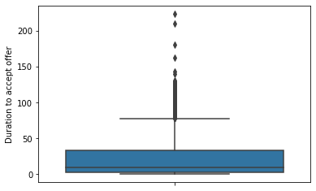

```python
sn.boxplot(y=df['Duration to accept offer'])
```

```python
df['Percent hike offered in CTC'].describe()
```

```
count    8995.000000
mean       40.657356
std        36.064060
min       -60.530000
25%        22.090000
50%        36.000000
75%        50.000000
max       471.430000
Name: Percent hike offered in CTC, dtype: float64
```

```python
df['Percent hike offered in CTC'].var()
```

```
1300.6164100437013
```

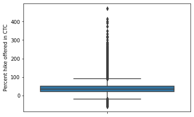

```python
sn.boxplot(y=df['Percent hike offered in CTC'])
```

```python
df.Age.describe()
```

```
count    8995.000000
mean       29.910506
std         4.092452
min        20.000000
25%        27.000000
50%        29.000000
75%        34.000000
max        60.000000
Name: Age, dtype: float64
```

```python
df.Age.var()
```

```
16.748160684728756
```

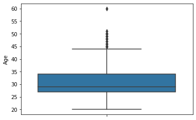

```python
sn.boxplot(y=df.Age)
```

### Categorical

```python
df.Status.value_counts(normalize=True)
```

```
Joined        0.813007
Not Joined    0.186993
Name: Status, dtype: float64
```

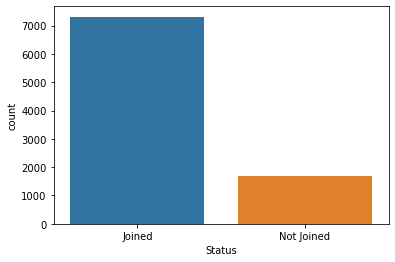

```python
sn.countplot(df.Status)
```

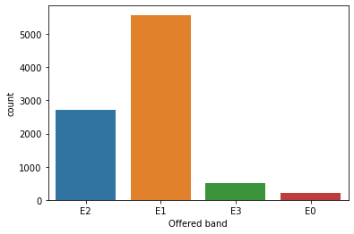

```python
sn.countplot(df['Offered band'])
```

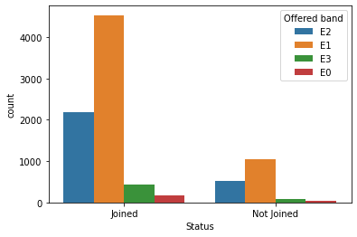

```python
sn.countplot(x=df['Status'],hue=df['Offered band'])
```

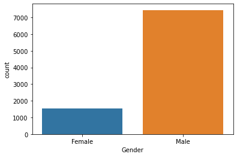

```python
sn.countplot(df.Gender)
```

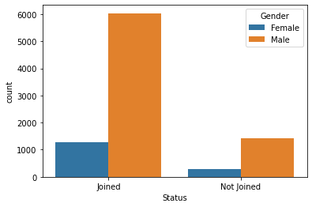

```python
sn.countplot(x=df['Status'],hue=df['Gender'])
```

```python
df.Location.value_counts()
```

```
Chennai      3150
Noida        2727
Bangalore    2230
Hyderabad     341
Mumbai        197
Gurgaon       146
Kolkata       129
Pune           48
Others         13
Cochin          8
Ahmedabad       6
Name: Location, dtype: int64
```

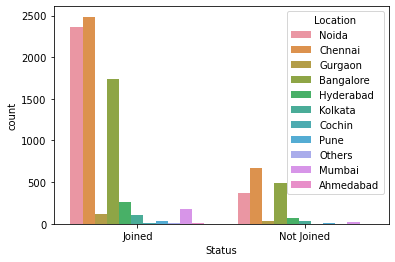

```python
sn.countplot(x=df['Status'],hue=df['Location'])
```

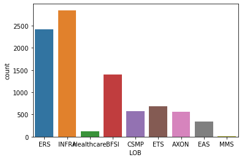

```python
sn.countplot(df.LOB)
```

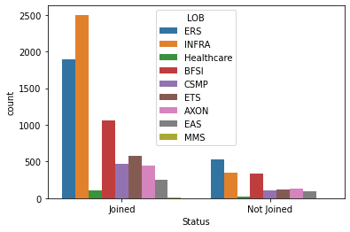

```python
sn.countplot(x=df['Status'],hue=df['LOB'])
```

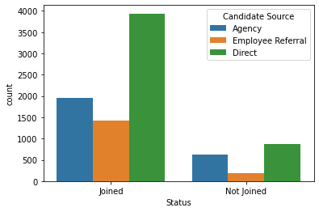

```python
sn.countplot(x=df['Status'],hue=df['Candidate Source'])
```

# Skewness and Kurtosis

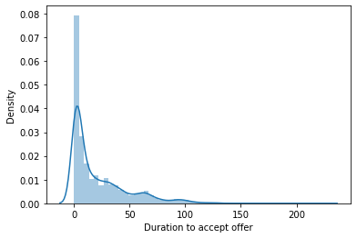

```python
sn.distplot(df['Duration to accept offer'])
```

```python
df['Duration to accept offer'].skew()
```

```
1.6155334734181757
```

The data for duration to accept offer is positive skewed

```python
df['Duration to accept offer'].kurtosis()
```

```
2.6573504381943884
```

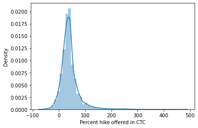

```python
sn.distplot(df['Percent hike offered in CTC'])
```

```python
df['Percent hike offered in CTC'].skew()
```

```
2.7550361867630553
```

The data for Percent hike offered in CTC is positive skewed

```python
df['Percent hike offered in CTC'].kurtosis()
```

```
15.932530321537978
```

kurtosis value is more than 3, so it can be said that data is leptokurtic

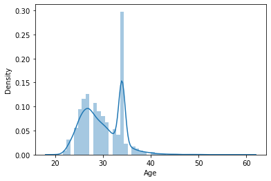

```python
sn.distplot(df['Age'])
```

```python
df['Age'].skew()
```

```
0.4155006013732649
```

The Age of candidates is positive skewed

```python
df['Age'].kurtosis()
```

```
0.3417585247643018
```

# Hypothesis for Duration to accept offer

alpha = 0.05

```python
st.shapiro(df['Duration to accept offer'])
```

```
ShapiroResult(statistic=0.7927267551422119, pvalue=0.0)
```

As we can observe the p-value is < alpha(0.05) we can say that the variable do not follow normal distribution

As the variable is a numerical variable we will now do non parametric test on this variable

```
H0: mean of population are equal
H1: mean of population are not equal
```

```python
dur = df['Duration to accept offer'].astype('str')
st.kruskal(dur,df.Status)
```

```
KruskalResult(statistic=14480.371467282952, pvalue=0.0)
```

As we observe p-value < alpha, Hence we can say that H0 is rejected and H1 is accepted

# Hypothesis for location

```python
table1 = pd.crosstab(df.Status, df.Location)
table1
```

| Location Status | Ahmedabad | Bangalore | Chennai | Cochin | Gurgaon | Hyderabad | Kolkata | Mumbai | Noida | Others | Pune |
| --- | --- | --- | --- | --- | --- | --- | --- | --- | --- | --- | --- |
| Joined | 5 | 1742 | 2486 | 7 | 118 | 266 | 100 | 176 | 2362 | 13 | 38 |
| Not Joined | 1 | 488 | 664 | 1 | 28 | 75 | 29 | 21 | 365 | 0 | 10 |

As both the variable are categorical we will use Chi-square test

```python
table1.describe()
```

| Location | Ahmedabad | Bangalore | Chennai | Cochin | Gurgaon | Hyderabad | Kolkata | Mumbai | Noida | Others | Pune |
| --- | --- | --- | --- | --- | --- | --- | --- | --- | --- | --- | --- |
| count | 2.000000 | 2.000000 | 2.000000 | 2.000000 | 2.00000 | 2.000000 | 2.000000 | 2.000000 | 2.000000 | 2.000000 | 2.00000 |
| mean | 3.000000 | 1115.000000 | 1575.000000 | 4.000000 | 73.00000 | 170.500000 | 64.500000 | 98.500000 | 1363.500000 | 6.500000 | 24.00000 |
| std | 2.828427 | 886.711904 | 1288.348555 | 4.242641 | 63.63961 | 135.057395 | 50.204581 | 109.601551 | 1412.092242 | 9.192388 | 19.79899 |
| min | 1.000000 | 488.000000 | 664.000000 | 1.000000 | 28.00000 | 75.000000 | 29.000000 | 21.000000 | 365.000000 | 0.000000 | 10.00000 |
| 25% | 2.000000 | 801.500000 | 1119.500000 | 2.500000 | 50.50000 | 122.750000 | 46.750000 | 59.750000 | 864.250000 | 3.250000 | 17.00000 |
| 50% | 3.000000 | 1115.000000 | 1575.000000 | 4.000000 | 73.00000 | 170.500000 | 64.500000 | 98.500000 | 1363.500000 | 6.500000 | 24.00000 |
| 75% | 4.000000 | 1428.500000 | 2030.500000 | 5.500000 | 95.50000 | 218.250000 | 82.250000 | 137.250000 | 1862.750000 | 9.750000 | 31.00000 |
| max | 5.000000 | 1742.000000 | 2486.000000 | 7.000000 | 118.00000 | 266.000000 | 100.000000 | 176.000000 | 2362.000000 | 13.000000 | 38.00000 |

```
H0: The variables are not associated
H1: The variables are associated
```

```python
x,pvalue,y,z = st.chi2_contingency(table1)
print(pvalue)
```

```
1.5784067706590078e-15
```

As we can observe p-value < alpha(0.05) --> We will reject H0 and Accept H1

### That is the location is associated with the Status of joining of candidate

# Hypothesis for Joining Bonus

```python
table2 = pd.crosstab(df.Status, df['Joining Bonus'])
table2
```

| Joining Bonus Status | No | Yes |
| --- | --- | --- |
| Joined | 6977 | 336 |
| Not Joined | 1601 | 81 |

```python
table2.describe()
```

| Joining Bonus | No | Yes |
| --- | --- | --- |
| count | 2.000000 | 2.000000 |
| mean | 4289.000000 | 208.500000 |
| std | 3801.406056 | 180.312229 |
| min | 1601.000000 | 81.000000 |
| 25% | 2945.000000 | 144.750000 |
| 50% | 4289.000000 | 208.500000 |
| 75% | 5633.000000 | 272.250000 |
| max | 6977.000000 | 336.000000 |

```
H0: The variables are not associated
H1: The variables are associated
```

```python
x,pvalue,y,z = st.chi2_contingency(table2)
print(pvalue)
```

```
0.7454707857023846
```

As we can observe p-value > alpha(0.05) --> We will accept H0

### That is the Joining Bonus is not associated with the Status of joining of candidate

# Hypothesis for Gender

```python
table3 = pd.crosstab(df.Status, df['Gender'])
table3
```

| Gender Status | Female | Male |
| --- | --- | --- |
| Joined | 1278 | 6035 |
| Not Joined | 273 | 1409 |

```python
table3.describe()
```

| Gender | Female | Male |
| --- | --- | --- |
| count | 2.000000 | 2.00000 |
| mean | 775.500000 | 3722.00000 |
| std | 710.642315 | 3271.07597 |
| min | 273.000000 | 1409.00000 |
| 25% | 524.250000 | 2565.50000 |
| 50% | 775.500000 | 3722.00000 |
| 75% | 1026.750000 | 4878.50000 |
| max | 1278.000000 | 6035.00000 |

```
H0: The variables are not associated
H1: The variables are associated
```

```python
x,pvalue,y,z = st.chi2_contingency(table3)
print(pvalue)
```

```
0.23679896899569233
```

As we can observe p-value > alpha(0.05) --> We will accept H0

### That is the Gender is not associated with the Status of joining of candidate

# Hypothesis for LOB

```python
table4 = pd.crosstab(df.Status, df['LOB'])
table4
```

| LOB Status | AXON | BFSI | CSMP | EAS | ERS | ETS | Healthcare | INFRA | MMS |
| --- | --- | --- | --- | --- | --- | --- | --- | --- | --- |
| Joined | 440 | 1059 | 472 | 254 | 1895 | 574 | 102 | 2502 | 15 |
| Not Joined | 128 | 337 | 107 | 92 | 531 | 117 | 22 | 348 | 0 |

```python
table4.describe()
```

| LOB | AXON | BFSI | CSMP | EAS | ERS | ETS | Healthcare | INFRA | MMS |
| --- | --- | --- | --- | --- | --- | --- | --- | --- | --- |
| count | 2.000000 | 2.000000 | 2.000000 | 2.000000 | 2.00000 | 2.000000 | 2.000000 | 2.000000 | 2.000000 |
| mean | 284.000000 | 698.000000 | 289.500000 | 173.000000 | 1213.00000 | 345.500000 | 62.000000 | 1425.000000 | 7.500000 |
| std | 220.617316 | 510.531096 | 258.093975 | 114.551299 | 964.49365 | 323.147799 | 56.568542 | 1523.108007 | 10.606602 |
| min | 128.000000 | 337.000000 | 107.000000 | 92.000000 | 531.00000 | 117.000000 | 22.000000 | 348.000000 | 0.000000 |
| 25% | 206.000000 | 517.500000 | 198.250000 | 132.500000 | 872.00000 | 231.250000 | 42.000000 | 886.500000 | 3.750000 |
| 50% | 284.000000 | 698.000000 | 289.500000 | 173.000000 | 1213.00000 | 345.500000 | 62.000000 | 1425.000000 | 7.500000 |
| 75% | 362.000000 | 878.500000 | 380.750000 | 213.500000 | 1554.00000 | 459.750000 | 82.000000 | 1963.500000 | 11.250000 |
| max | 440.000000 | 1059.000000 | 472.000000 | 254.000000 | 1895.00000 | 574.000000 | 102.000000 | 2502.000000 | 15.000000 |

```
H0: The variables are not associated
H1: The variables are associated
```

```python
x,pvalue,y,z = st.chi2_contingency(table4)
print(pvalue)
```

```
8.393814703388281e-28
```

As we can observe p-value < alpha(0.05) --> We will reject H0 --> Accept H1

### That is the LOB associated with the Status of joining of candidate

# Hypothesis for Percent hike in CTC

alpha = 0.05

```python
st.shapiro(df['Percent hike offered in CTC'])
```

```
ShapiroResult(statistic=0.8044019341468811, pvalue=0.0)
```

As we can observe the p-value is < alpha(0.05) we can say that the variable do not follow normal distribution

As the variable is a numerical variable we will now do non parametric test on this variable

```
H0: mean of population are equal
H1: mean of population are not equal
```

```python
per = df['Percent hike offered in CTC'].astype('str')
st.kruskal(per,df.Status)
```

```
KruskalResult(statistic=14476.678619914197, pvalue=0.0)
```

As we observe p-value < alpha, Hence we can say that H0 is rejected and H1 is accepted

# Hypothesis for Age

alpha = 0.05

```python
st.shapiro(df['Age'])
```

```
ShapiroResult(statistic=0.9441733360290527, pvalue=0.0)
```

As we can observe the p-value is < alpha(0.05) we can say that the variable do not follow normal distribution

As the variable is a numerical variable we will now do non parametric test on this variable

```
H0: mean of population are equal
H1: mean of population are not equal
```

```python
age = df['Age'].astype('str')
st.kruskal(age,df.Status)
```

```
KruskalResult(statistic=14509.80968687641, pvalue=0.0)
```

As we observe p-value < alpha, Hence we can say that H0 is rejected and H1 is accepted

# Hypothesis for Offered Band

```python
tab = pd.crosstab(df.Status, df['Offered band'])
tab
```

| Offered band Status | E0 | E1 | E2 | E3 |
| --- | --- | --- | --- | --- |
| Joined | 161 | 4536 | 2188 | 428 |
| Not Joined | 50 | 1042 | 516 | 74 |

```python
tab.describe()
```

| Offered band | E0 | E1 | E2 | E3 |
| --- | --- | --- | --- | --- |
| count | 2.000000 | 2.000000 | 2.000000 | 2.000000 |
| mean | 105.500000 | 2789.000000 | 1352.000000 | 251.000000 |
| std | 78.488853 | 2470.631093 | 1182.282538 | 250.315801 |
| min | 50.000000 | 1042.000000 | 516.000000 | 74.000000 |
| 25% | 77.750000 | 1915.500000 | 934.000000 | 162.500000 |
| 50% | 105.500000 | 2789.000000 | 1352.000000 | 251.000000 |
| 75% | 133.250000 | 3662.500000 | 1770.000000 | 339.500000 |
| max | 161.000000 | 4536.000000 | 2188.000000 | 428.000000 |

```
H0: The variables are not associated
H1: The variables are associated
```

```python
x,pvalue,y,z = st.chi2_contingency(tab)
print(pvalue)
```

```
0.030612795734516418
```

As we can observe p-value < alpha(0.05) --> We will reject H0 --> Accept H1

### That is the Offered Band associated with the Status of joining of candidate

# Hypothesis for Relocation

```python
tab = pd.crosstab(df.Status, df['Candidate relocate actual'])
tab
```

| Candidate relocate actual Status | No | Yes |
| --- | --- | --- |
| Joined | 6023 | 1290 |
| Not Joined | 1682 | 0 |

```python
tab.describe()
```

| Candidate relocate actual | No | Yes |
| --- | --- | --- |
| count | 2.000000 | 2.000000 |
| mean | 3852.500000 | 645.000000 |
| std | 3069.550537 | 912.167748 |
| min | 1682.000000 | 0.000000 |
| 25% | 2767.250000 | 322.500000 |
| 50% | 3852.500000 | 645.000000 |
| 75% | 4937.750000 | 967.500000 |
| max | 6023.000000 | 1290.000000 |

```
H0: The variables are not associated
H1: The variables are associated
```

```python
x,pvalue,y,z = st.chi2_contingency(tab)
print(pvalue)
```

```
5.352550694431075e-77
```

As we can observe p-value < alpha(0.05) --> We will reject H0 --> Accept H1

### That is the Relocation is associated with the Status of joining of candidate

# Hypothesis for Notice Period

```python
df['Notice period'].describe()
```

```
count    8995.000000
mean       39.291829
std        22.220239
min         0.000000
25%        30.000000
50%        30.000000
75%        60.000000
max       120.000000
Name: Notice period, dtype: float64
```

alpha = 0.05

```python
st.shapiro(df['Notice period'])
```

```
ShapiroResult(statistic=0.8241329193115234, pvalue=0.0)
```

As we can observe the p-value is < alpha(0.05) we can say that the variable do not follow normal distribution

As the variable is a numerical variable we will now do non parametric test on this variable

```
H0: mean of population are equal
H1: mean of population are not equal
```

```python
age = df['Notice period'].astype('str')
st.kruskal(age,df.Status)
```

```
KruskalResult(statistic=14869.172569741255, pvalue=0.0)
```

As we observe p-value < alpha, Hence we can say that H0 is rejected and H1 is accepted

# Hypothesis for experience

```python
df['Rex in Yrs'].describe()
```

```
count    8995.000000
mean        4.239022
std         2.547571
min         0.000000
25%         3.000000
50%         4.000000
75%         6.000000
max        24.000000
Name: Rex in Yrs, dtype: float64
```

alpha = 0.05

```python
st.shapiro(df['Rex in Yrs'])
```

```
ShapiroResult(statistic=0.9065451622009277, pvalue=0.0)
```

As we can observe the p-value is < alpha(0.05) we can say that the variable do not follow normal distribution

As the variable is a numerical variable we will now do non parametric test on this variable

```
H0: mean of population are equal
H1: mean of population are not equal
```

```python
age = df['Rex in Yrs'].astype('str')
st.kruskal(age,df.Status)
```

```
KruskalResult(statistic=14532.771039126746, pvalue=0.0)
```

As we observe p-value < alpha, Hence we can say that H0 is rejected and H1 is accepted

# Hypothesis for Candidate Source

```python
tab = pd.crosstab(df.Status, df['Candidate Source'])
tab
```

| Candidate Source Status | Agency | Direct | Employee Referral |
| --- | --- | --- | --- |
| Joined | 1960 | 3937 | 1416 |
| Not Joined | 625 | 864 | 193 |

```python
tab.describe()
```

| Candidate Source | Agency | Direct | Employee Referral |
| --- | --- | --- | --- |
| count | 2.000000 | 2.000000 | 2.000000 |
| mean | 1292.500000 | 2400.500000 | 804.500000 |
| std | 943.987553 | 2172.939139 | 864.791593 |
| min | 625.000000 | 864.000000 | 193.000000 |
| 25% | 958.750000 | 1632.250000 | 498.750000 |
| 50% | 1292.500000 | 2400.500000 | 804.500000 |
| 75% | 1626.250000 | 3168.750000 | 1110.250000 |
| max | 1960.000000 | 3937.000000 | 1416.000000 |

```
H0: The variables are not associated
H1: The variables are associated
```

```python
x,pvalue,y,z = st.chi2_contingency(tab)
print(pvalue)
```

```
1.7724032717836757e-22
```

As we can observe p-value < alpha(0.05) --> We will reject H0 --> Accept H1

### That is the Candidate Source is associated with the Status of joining of candidate